# Final Project

December 6, 2018

## Introduction

The prominent usage of technology and explosion of wireless communication has dramatically improved our world. However, there exists a global digital divide that includes massive disparities regarding the connection speed, quality and accessibility.

In our project, we use three assumptions (same time, same people and correct dataset) to define internet usage, which is the quotient of the number of internet user over the country's population to describe internet usage. We also used statistical methods to find the impact of democracy, education, economy, and health on internet usage.

## Objectives

Examining the relationship between our definition of internet usage and four specific factors:

1. Democracy
2. Education
3. Economy
4. Health

Is there more to this?

- Establish a general conclusion on what may impact the proportion of internet usage.

## Statistical Methods

- Boxplot
- Classification Tree
- Data Wrangling
- Linear Regression
- Scatterplot

## Internet usage around the world

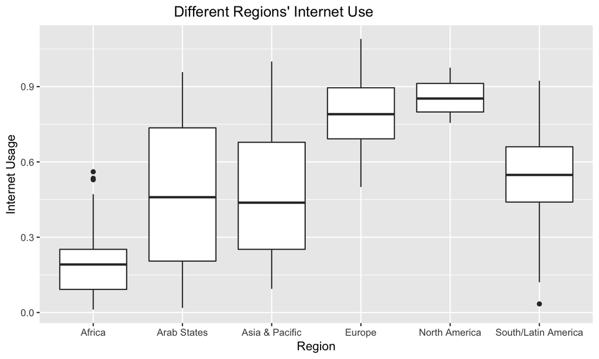

## Internet usage around the world

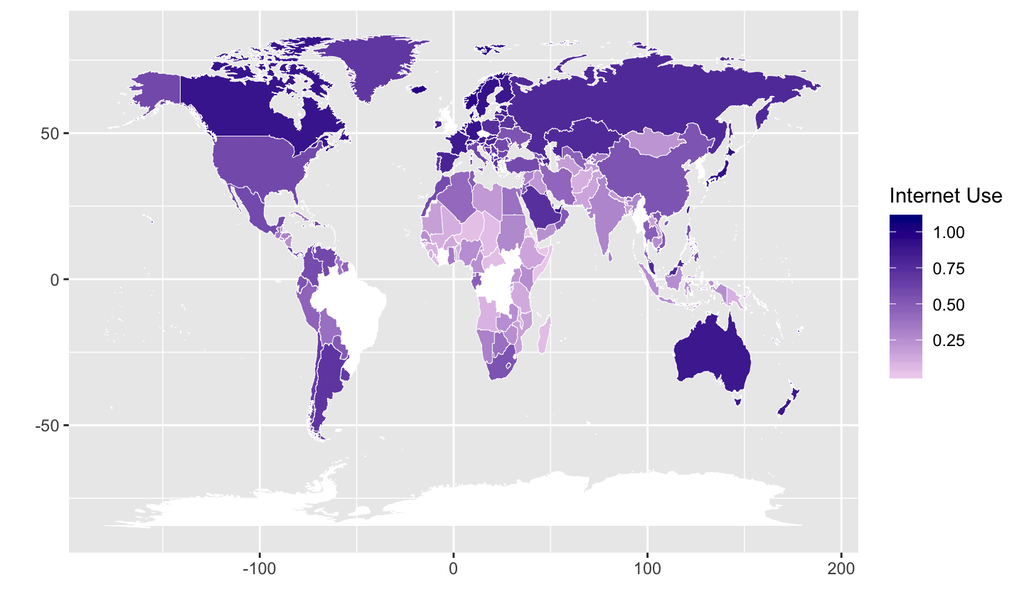

Internet usage around the world.

## Democracy

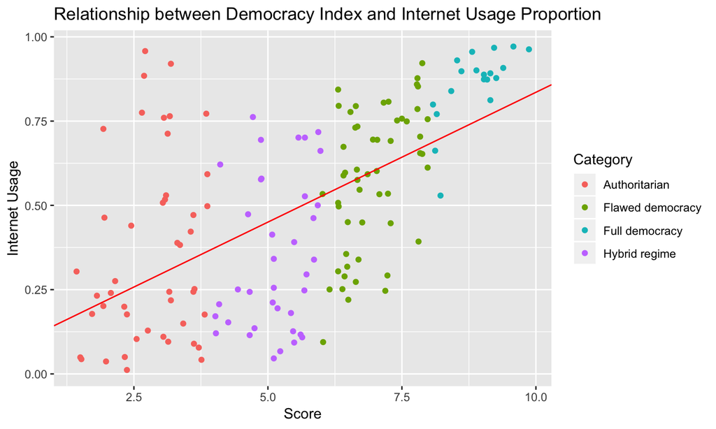

## Democracy

Analyzing the relationship between democracy index and internet usage

- Dependent variable (y): Proportion of Internet Usage from 2016-2017
- Independent variable (x): Score in 2017 (definition of democracy according to the dataset)

```
## Observations: 155
## Variables: 4
## $ Country    <chr> "Norway", "Iceland", "Sweden", "New Zealand", "Denm...
## $ Score      <chr> "9.87", "9.58", "9.39", "9.26", "9.22", "9.15", "9....
## $ Category   <chr> "Full democracy", "Full democracy", "Full democracy...
## $ proportion <dbl> 0.9629437, 0.9712139, 0.9077294, 0.8776840, 0.96757...
```

## Democracy

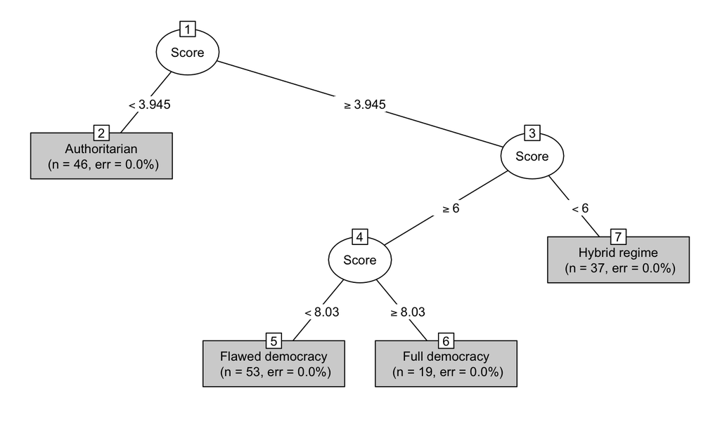

## Education

Analyzing the relationship between percentage of GDP allocated towards education and internet usage

- Dependent variable (y): Proportion of Internet Usage from 2016-2017
- Independent variable (x): Percentage of a government's GDP allocated towards education

```
## Observations: 171
## Variables: 3
## $ Country     <chr> "Lesotho", "Cuba", "Marshall Islands", "Kiribati",...
## $ percent_gdp <dbl> 13.0, 12.8, 12.2, 12.0, 9.5, 9.5, 9.4, 8.7, 8.4, 8...
## $ proportion  <dbl> 0.27290528, 0.38879194, 0.29322905, 0.13545703, 0....
```

## Education

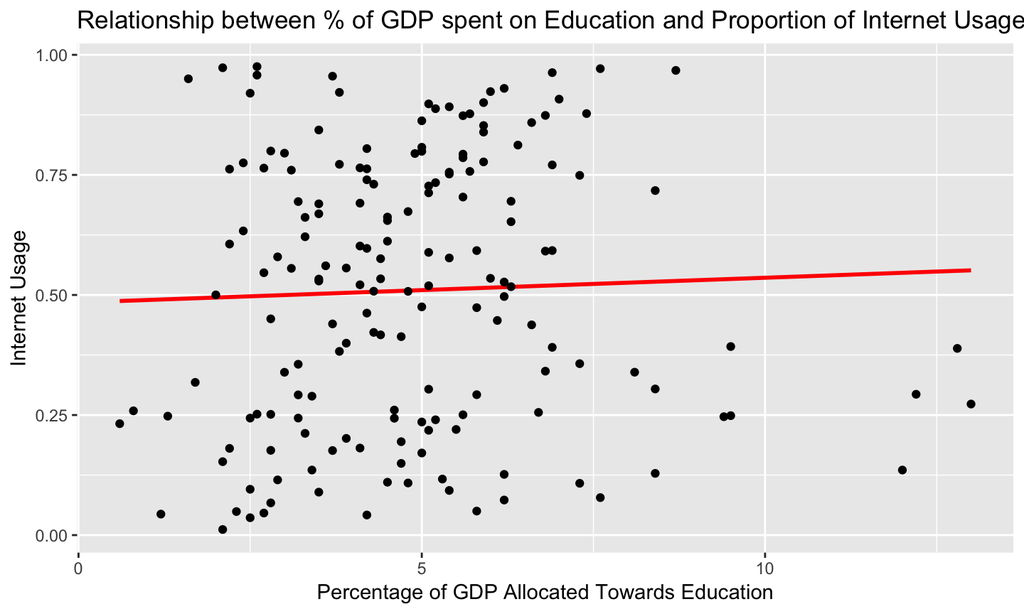

## Economy

Analyzing the relationship between GDP - PER CAPITA (PPP) and internet usage

- Dependent variable (y): Proportion of Internet Usage from 2016-2017
- Independent variable (x): The log of a country's (GDP - PER CAPITA (PPP))

```
## Observations: 220
## Variables: 3
## $ Country                        <chr> "Liechtenstein", "Qatar", "Mona...
## $ `log (GDP - PER CAPITA (PPP))` <dbl> 11.84295, 11.73206, 11.65876, 1...
## $ proportion                     <dbl> 0.9730677, 0.9200854, 0.9501061...
```

## Economy

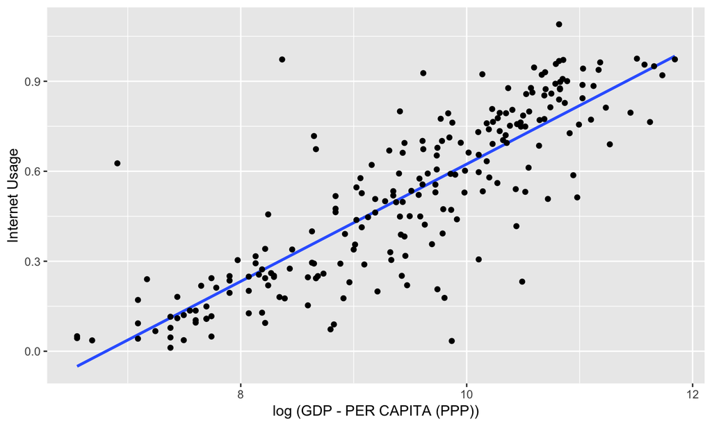

## Economy

Analyzing the relationship between the GDP in $ that is spent on education and internet usage

- Dependent variable (y): Proportion of Internet Usage from 2016-2017
- Independent variable (x): The dollar amount of (GDP - PER CAPITA (PPP)) that is spent on Education

```
## Observations: 171
## Variables: 3
## $ Country                       <chr> "Lesotho", "Cuba", "Marshall Isl...
## $ `GDP in $ spent on Education` <dbl> 468.0, 1574.4, 414.8, 240.0, 169...
## $ proportion                    <dbl> 0.27290528, 0.38879194, 0.293229...
```

## Economy

We use the hypothesis test to test if there is a relationship between the internet use and the logarithm of the money spent on education per person.

The null hypothesis is the coefficient of the regression line is zero, while the alternative hypothesis is the coefficient of the line is non-zero.

## Economy

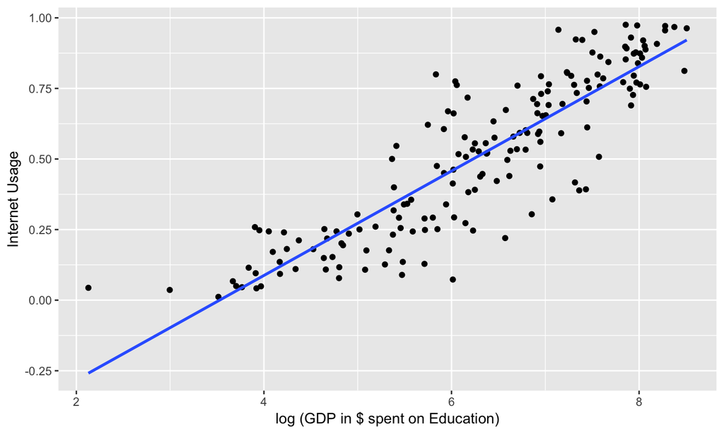

## Economy

After the test, we got the p value is ‘4.926093e-56’ which is extremely small

Thus we have strong evidence against the null hypothesis and say there is actually an relationship between the internet use and the logarithm of the money spent on education

```
##             Estimate Std. Error  t value     Pr(>|t|)
## (Intercept) 4.156400  0.1015189 40.94212 1.209413e-89
## proportion  4.169991  0.1746418 23.87739 4.926093e-56
```

## Economy

Analyzing the relationship between the GDP in $ that is spent on health and internet usage

- Dependent variable (y): Proportion of Internet Usage from 2016-2017
- Independent variable (x): The dollar amount of (GDP - PER CAPITA (PPP)) that is spent on health

```
## Observations: 190
## Variables: 3
## $ Country                          <chr> "Qatar", "Monaco", "Luxembour...
## $ `log (GDP in $ spent on Health)` <dbl> 12.52052, 13.11737, 13.46109,...
## $ proportion                       <dbl> 0.9200854, 0.9501061, 0.95551...
```

## Economy

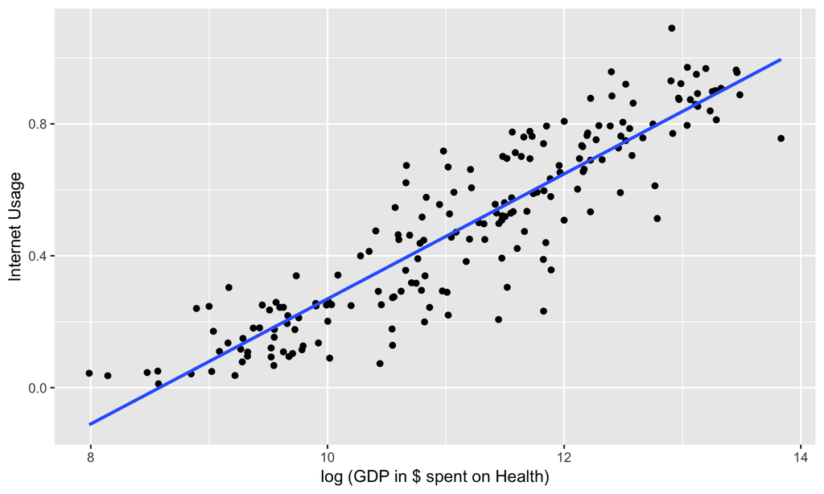

## Health

Analyzing the relationship between the health expectancy and internet usage

- Dependent variable (y): Proportion of Internet Usage from 2016-2017
- Independent variable (x): Health Expectancy of a country

```
## Observations: 217
## Variables: 3
## $ Country    <chr> "Monaco", "Japan", "Singapore", "Macau", "San Marin...
## $ `(YEARS)`  <dbl> 89.4, 85.3, 85.2, 84.6, 83.3, 83.1, 83.0, 82.9, 82....
## $ proportion <dbl> 0.9501061, 0.9218242, 0.7952554, 0.7641590, 0.51286...
```

## Health

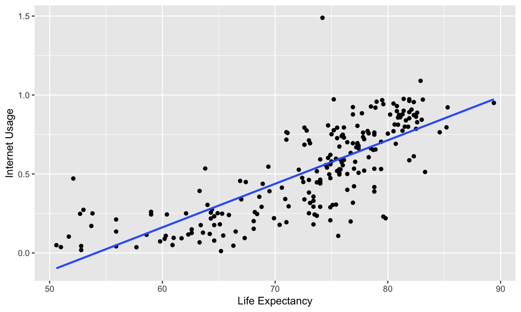

## HDI

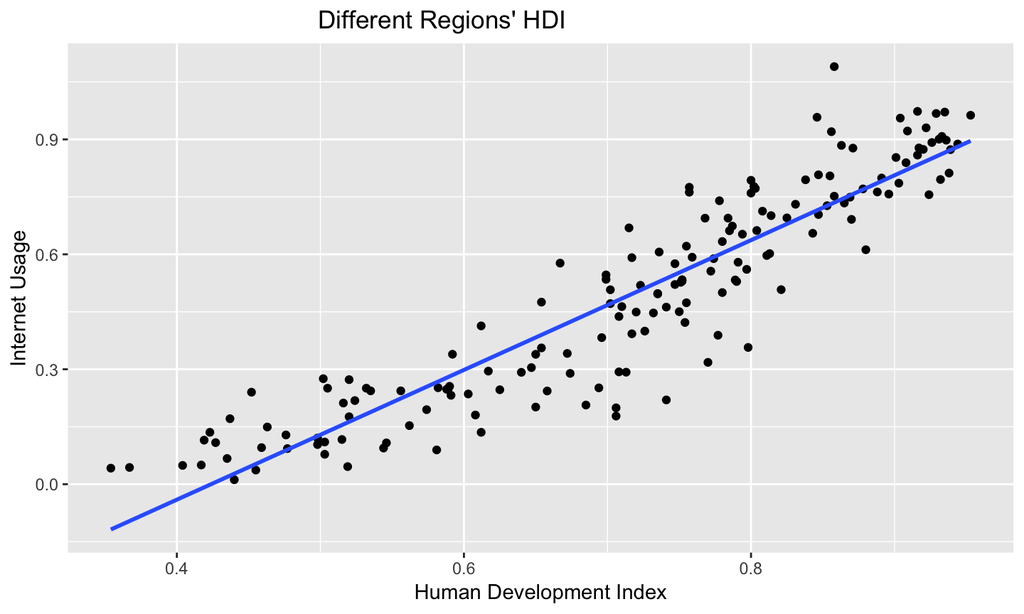

## Conclusion

In general, the more that people in a country spend, the larger the proportion of internet users there are in a country. Health and democracy both have a positive linear relationship with internet usage. The higher percent of people spend on education does not imply a larger proportion of internet users.